# Frequency Analyses of Weather Events

# Introduction

This R Notebook contains code analyzing weather data from the Portland Jetport for inclusion in the 2020 State of the Bay Report. The primary focus in on statistical models, but selected graphics are included to aid interpretation.

This R Notebook focuses on long-term (80 year) changes in frequency of extreme events, including cold days, hot days, and high rainfall days.

# Install Libraries

```r
library(tidyverse)
library(readr)
library(ggthemes)
#library(extrafont)
```

## Read Data

```r
sibfldnm <- 'Original Data'
parent <- dirname(getwd())
sibling <- paste(parent,sibfldnm, sep = '/')
fn <- 'longannualdata.csv'

longannualdata <- read_csv(paste(sibling,fn, sep = '/')) %>%
  select(-station) %>%
  mutate(year = as.numeric(format(date, format='%Y'))) %>%
  mutate(cyear = year-1980)
```

# Temperature Exceedences

The Annual Data Downloaded from NOAA’s Climate Data Online includes counts of the number of days exceeding various temperature thresholds, as follows:

1. DX90: Number of days with maximum temperature >= 32.2°C/90°F.
2. DX70: Number of days with maximum temperature >= 21.1°C/70°F.
3. DX32: Number of days with maximum temperature <= 0°C/32°F.
4. DT32: Number of days with minimum temperature <= 0°C/32°F.
5. DT00: Number of days with minimum temperature <= -17.8°C/0°F.

We focus on days that got over over 90 Fahrenheit, days that dropped below 32, and days that got as low as 0 degrees F. Notice that even though the CDO data was downloaded in metric units, these cumulative counts are based on English units.

```r
textdatalong <- longannualdata %>%
  filter(datatype %in% c('DX90', 'DT32', 'DT00'))

textdata <- longannualdata %>%
  filter(datatype %in% c('DX90', 'DT32', 'DT00')) %>%
  spread(key = datatype, value = value)

# The following is to test binomial GLMs
doy <- tibble(year = 1941:2019, days = rep(365, 2020-1941)) %>%
mutate(days = ifelse((year %% 4 == 0) & (year!=2000), 366, 365))

textdata <- textdata %>%
  mutate(days = doy$days)
```

# Generalized Linear Models

These are count data, suggesting either Poisson or binomial models. Technically, since the total number of days in a year is limited (to 365 days – 366 for leap years), a binomial GLM might be considered correct, but for low counts, (as observed for most of these variables) the difference is immaterial, and the assumptions of a Poisson model are adequately met. For high counts, a binomial distribution will converge on a normal distribution, suggesting a standard linear model.

Several variables show evidence of over-dispersion compared to a Poisson model, which suggests looking at quasi-Poisson models.

The Poisson Models are convenient in this setting because the canonical link for the Poisson model is log, which is easier to work with than the canonical link for binomial GLMs (logistic).

## Poisson Models

```r
gt90GLM <- glm(DX90 ~ year, family = poisson, data = textdata)
lt32GLM <- glm(DT32 ~ year, family = poisson, data = textdata)
lt00GLM <- glm(DT00 ~ year, family = poisson, data = textdata)

gt90GLM_q <- glm(DX90 ~ year, family = quasipoisson, data = textdata)
lt32GLM_q <- glm(DT32 ~ year, family = quasipoisson, data = textdata)
lt00GLM_q <- glm(DT00 ~ year, family = quasipoisson, data = textdata)
```

## Test Other Models

Here we try binomial and Gaussian models, on the days less than freezing data, to examine whether it is likely that selection of models would have any effect on our conclusions.

```r
#Set up response variable for binomial model
rDT32 <- cbind(textdata$DT32, textdata$days-textdata$DT32)
lt32GLM_b <- glm(rDT32 ~ year, family = binomial, data = textdata)

lt32LM <- lm(DT32 ~ year, data = textdata)

summary(lt32GLM_b)
```

```
Call:
glm(formula = rDT32 ~ year, family = binomial, data = textdata)

Deviance Residuals:
    Min       1Q   Median       3Q      Max
-2.5489  -0.7387   0.1495   0.7867   2.1775

Coefficients:
              Estimate Std. Error z value Pr(>|z|)
(Intercept)  6.9990714  1.0379387   6.743 1.55e-11 ***
year        -0.0037021  0.0005243  -7.062 1.65e-12 ***
---
Signif. codes:  0 ‘***’ 0.001 ‘**’ 0.01 ‘*’ 0.05 ‘.’ 0.1 ‘ ’ 1

(Dispersion parameter for binomial family taken to be 1)

    Null deviance: 134.998  on 78  degrees of freedom
Residual deviance:  85.052  on 77  degrees of freedom
AIC: 588.44

Number of Fisher Scoring iterations: 3
```

```r
summary(lt32LM)
```

```
Call:
lm(formula = DT32 ~ year, data = textdata)

Residuals:
    Min      1Q  Median      3Q     Max
-24.010  -7.066   1.264   7.284  21.030

Coefficients:
             Estimate Std. Error t value Pr(>|t|)
(Intercept) 803.72785   97.06788   8.280 2.94e-12 ***
year         -0.32880    0.04902  -6.707 2.96e-09 ***
---
Signif. codes:  0 ‘***’ 0.001 ‘**’ 0.01 ‘*’ 0.05 ‘.’ 0.1 ‘ ’ 1

Residual standard error: 9.936 on 77 degrees of freedom
Multiple R-squared:  0.3688,    Adjusted R-squared:  0.3606
F-statistic: 44.99 on 1 and 77 DF,  p-value: 2.963e-09
```

### Compare model trend lines

```r
logit <- function (p) {log(p/(1-p))}
logistic <- function (p) {exp(p)/(exp(p)+1)}
lines <- tibble(cyr = seq(1941,2019),
          lt32_p = exp(coef(lt32GLM)[1] + coef(lt32GLM)[2] * seq(1941,2019) ),
          lt32_b = 365*logistic(coef(lt32GLM_b)[1] + coef(lt32GLM_b)[2]  * seq(1941,2019) ),
          lt32_l = coef(lt32LM)[1] + coef(lt32LM)[2]*seq(1941,2019) )

plt <- ggplot(textdata, aes(x=year))+
  geom_line(aes(y=DT32)) +
  geom_line(data = lines, aes(x=cyr, y=lt32_p), lty=2, color='blue') +
  geom_line(data = lines, aes(x=cyr, y=lt32_b), lty=2, color='green') +
  geom_line(data = lines, aes(x=cyr, y=lt32_l), lty=2, color='red') +

  xlab('Year') +
  ylab("Days")
plt
```

[output not shown]

So, all three models provide nearly identical predictions and qualitative conclusions. It appears our qualitative conclusions are unaffected by model selection.

### Greater than 90 Degree Days

```r
summary(gt90GLM)
```

```
Call:
glm(formula = DX90 ~ year, family = poisson, data = textdata)

Deviance Residuals:
    Min       1Q   Median       3Q      Max
-3.2533  -1.4081  -0.2842   1.0077   3.6799

Coefficients:
             Estimate Std. Error z value Pr(>|z|)
(Intercept)  7.554640   4.360787   1.732   0.0832 .
year        -0.003001   0.002204  -1.362   0.1733
---
Signif. codes:  0 ‘***’ 0.001 ‘**’ 0.01 ‘*’ 0.05 ‘.’ 0.1 ‘ ’ 1

(Dispersion parameter for poisson family taken to be 1)

    Null deviance: 216.87  on 78  degrees of freedom
Residual deviance: 215.01  on 77  degrees of freedom
AIC: 462.56

Number of Fisher Scoring iterations: 5
```

```r
summary(gt90GLM_q)
```

```
Call:
glm(formula = DX90 ~ year, family = quasipoisson, data = textdata)

Deviance Residuals:
    Min       1Q   Median       3Q      Max
-3.2533  -1.4081  -0.2842   1.0077   3.6799

Coefficients:
             Estimate Std. Error t value Pr(>|t|)
(Intercept)  7.554640   6.949191   1.087    0.280
year        -0.003001   0.003512  -0.855    0.395

(Dispersion parameter for quasipoisson family taken to be 2.539445)

    Null deviance: 216.87  on 78  degrees of freedom
Residual deviance: 215.01  on 77  degrees of freedom
AIC: NA

Number of Fisher Scoring iterations: 5
```

```r
#anova(gt90GLM, test = "LRT")
```

So no increase in number of days exceeding 90 degrees. Quasi-Poisson addresses the elevated residual deviance, but does not change the conclusions.

### Days Freezing

```r
summary(lt32GLM)
```

[output not shown]

Significant declines in the number of days dipping below freezing. No obvious violations of model assumptions. Quasipoisson here identifies slight under-dispersion, but does not change underlying conclusions.

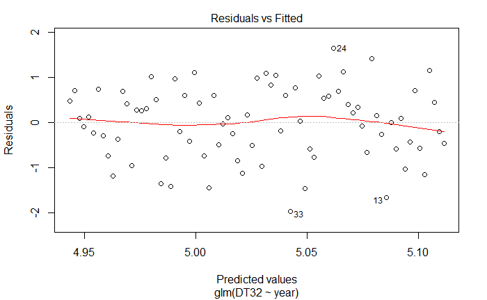

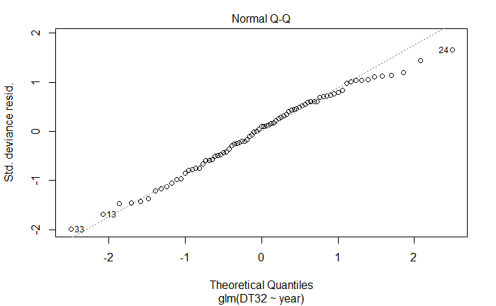

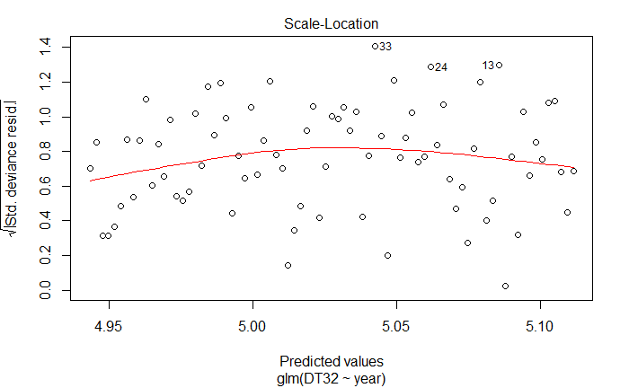

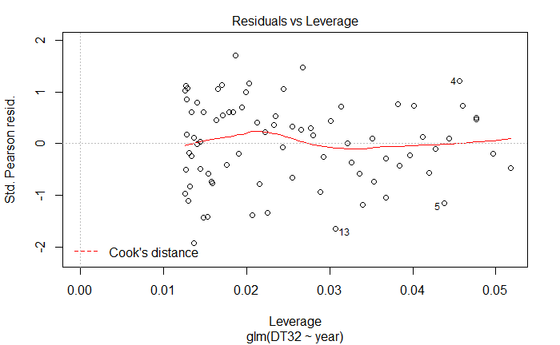

```r
plot(lt32GLM)
```

#### Days Less Than Zero

```r
summary(lt00GLM)
```

[output not shown]

```r
summary(lt00GLM_q)
```

```
Call:
glm(formula = DT00 ~ year, family = quasipoisson, data = textdata)

Deviance Residuals:
    Min       1Q   Median       3Q      Max
-4.4480  -1.2130  -0.3404   1.0691   3.5683

Coefficients:
             Estimate Std. Error t value Pr(>|t|)
(Intercept) 32.810472   5.420854   6.053 4.84e-08 ***
year        -0.015379   0.002748  -5.595 3.23e-07 ***
---
Signif. codes:  0 ‘***’ 0.001 ‘**’ 0.01 ‘*’ 0.05 ‘.’ 0.1 ‘ ’ 1

(Dispersion parameter for quasipoisson family taken to be 3.252358)

    Null deviance: 371.27  on 78  degrees of freedom
Residual deviance: 265.70  on 77  degrees of freedom
AIC: NA

Number of Fisher Scoring iterations: 5
```

```r
#anova(lt00GLM, test = "LRT")
```

Highly significant decrease in days dropping below zero. QuasiPoisson addresses moderate over-dispersion, but does not change the substantive conclusions. I prefer the quasi poison model here.

For plotting purposes, note that all model parameters are identical between Poisson and Quasi-Poisson models. It is only the dispersion that differs.